# Fig1

N Toyohara

#a_vec <- c(4,6,8,10, 12,14, 16,24) # #

[figure not shown]

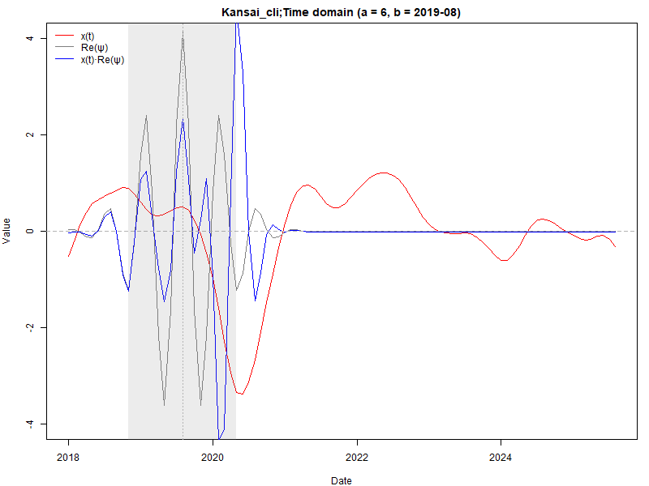

#

[figure not shown]

#

[figure not shown]

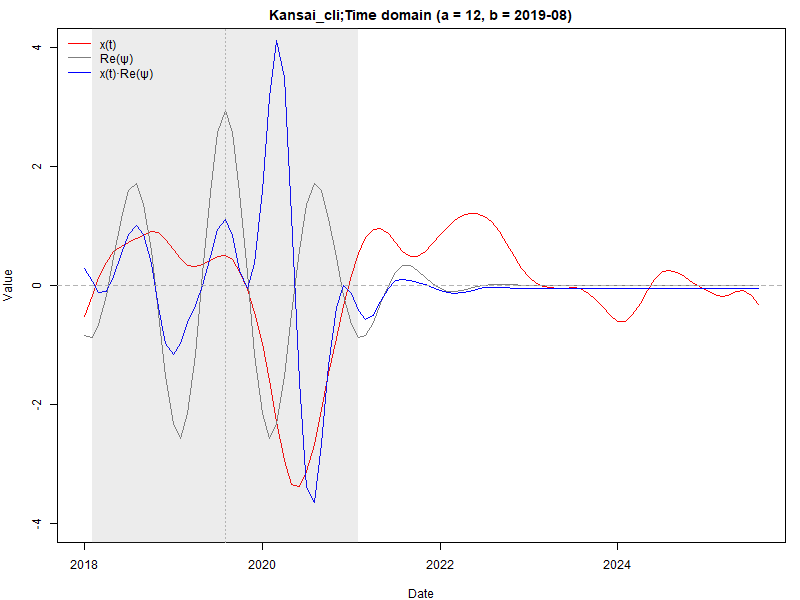

#

[figure not shown]

#

[figure not shown]

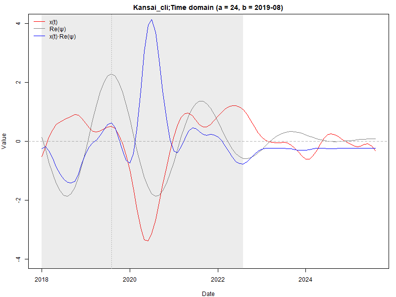

#

[figure not shown]

ChatGPT:以下は、**提示いただいた a = 24, 16, 14, 12, 10, 8, 6, 4 の各図を横断的に比較し、「Morlet の Re(ψ) と x(t)·Re(ψ) の時間領域での姿をどう評価できるか」**を、 ①周期（月数）別の特徴、②2020 年ショック前後の見え方、③COI（端効果）との関係、④最適な a（周期帯）候補、⑤論文用の書き方の5点から整理してまとめます。

◆ 1. 周期帯（a）の違いが図にどう表れているか ● a = 24（長周期 ≈ 24か月）

Re(ψ) はゆっくりとした振動で、2020 年の谷（CLI 急落部分）を最も綺麗に捉えている。

x(t)·Re(ψ)（青）は 2020 年前後で大きく正→負→正と振れ、長周期成分がコロナショックの大波動を強く拾っていることが明確。

CLI の実体的な景気循環（年〜2年の景気波動）に一致しており、もっとも「経済学的に意味のある」周期帯。

● a = 16（中長周期 ≈ 16か月）

a=24 と同様に 2020 年谷を中心とした大きな波動が再現されるが、 a=24 に比べて波形がやや細かく、振幅も少し強調される。

CLI の山谷と Re(ψ) の山谷がよく整合し、信号抽出として非常に安定。

● a = 14 / 12（中周期 ≈ 12〜14か月）

振動が細かくなり、コロナショックの急落をより鋭く捉える。

x(t)·Re(ψ) は2020年に鋭いピークを持ち、短めの景気循環（1年前後）が強く現れている。

CLI の短期回復・反動増減のような「短めの調整波動」が強調されており、早めの景気転換点検知に有効。

● a = 10 / 8（短周期 ≈ 8〜10か月）

Re(ψ) の振幅が 2020 年前後で非常に大きくなり、ノイズ的な高周波成分も拾い始める。

波動は CLI 実系列より速く振動し、x(t)·Re(ψ) は深く鋭いピーク・谷を描く。

経済的意味は残るが、ノイズも混ざる「中短期の不安定領域」。

● a = 6 / 4（超短周期 ≈ 4〜6か月）

Re(ψ) が「高速振動」になり、x(t) の僅かな凹凸にも反応。

x(t)·Re(ψ) は非常に鋭い振れを2020年前後に示すが、 経済的信号というよりノイズへの感応が増えている。

経済学的にはこの帯域は「短期ショック（在庫調整・月次異常値等）」を見るときのみ有効。

◆ 2. 2020 年ショック（コロナ）を軸にした比較 ● a が大きいほど（= 長周期ほど）

ショックは滑らかな 1 つの大波動として視覚化される。

CLI の「景気循環としての谷」を最も経済学的に表現している。

● a が小さくなるほど（短周期ほど）

2020 年付近で Re(ψ) の振動数が増え、 ショックの谷 → 反発 → 再調整が複数の波として細かく可視化される。

ただし a ≤ 6 はノイズを拾い、政策ショックや月次混乱を強く反映しすぎる。

◆ 3. COI（端効果）との関係 あなたが指摘したロジック：

グレーの領域が両端にかかる → 乱数で発生している部分が増える → 信頼度が落ちる → COI領域外になる

◆ 4. 最適な a（論文・説明に使うべき周期帯） 次の3つの観点で選ぶとよい。 ◎ 経済学的に一番妥当： a ≈ 12〜24（12–24か月周期）

景気循環（月次ベースで1〜2年周期）と一致

ノイズが少なく、波形が安定

CLI の役割（先行指数）を示しやすい → 論文用の静止画は a = 12, 16, 24 が最適。

○ ショックの鋭い動きを見せたいとき a ≈ 8–10 → 2020年ショックの階段的の動きを強調 △ ノイズ性・端効果が大きく注意が必要 a ≈ 4–6 → 使う場合は必ず「短周期はノイズ混入の可能性」と但し書きを入れる。

◆ 総合評価（簡潔まとめ）

a=24,16,12 は CLI の景気循環（本質的成分）を最もよく表す。

a=8,10 はショックの鋭さを強調したい場合に有効だがノイズ感増。

論文では 12〜24 を使い、他は補論（付録）に回す構成が最適。